# AS10-3：SPAM or HAM

卓雍然 D994010001

2018-08-12 18:34:21

```r
packages = c(
  "dplyr","ggplot2","caTools","tm","SnowballC","ROCR","rpart",
  "rpart.plot","randomForest")
existing = as.character(installed.packages()[,1])
for(pkg in packages[!(packages %in% existing)]) install.packages(pkg)
```

```r
rm(list=ls(all=TRUE))
Sys.setlocale("LC_ALL","C")
```

```
## [1] "C"
```

```r
options(digits=5, scipen=10)

library(dplyr)
library(tm)
library(SnowballC)
library(ROCR)
library(caTools)
library(rpart)
library(rpart.plot)
library(randomForest)
```

### Problem 1 - Exploration

```r
D = read.csv("data/emails.csv", stringsAsFactors = F)
```

##### 1.1 How many emails are in the dataset?

```r
nrow(D)
```

```
## [1] 5728
```

##### 1.2 How many of the emails are spam?

```r
table(D$spam)
```

```
##
##    0    1
## 4360 1368
```

##### 1.3 Which word appears at the beginning of every email in the dataset?

```r
substr(D$text[1:5], 1, 60)
```

```
## [1] "Subject: naturally irresistible your corporate identity  lt "
## [2] "Subject: the stock trading gunslinger  fanny is merrill but "
## [3] "Subject: unbelievable new homes made easy  im wanting to sho"
## [4] "Subject: 4 color printing special  request additional inform"
## [5] "Subject: do not have money , get software cds from here !  s"
```

##### 1.4 Words in every document

【P1.4】*Could a spam classifier potentially benefit from including the frequency of the word that appears in every email?*

- Yes – the number of times the word appears might help us differentiate spam from ham

##### 1.5 How many characters are in the longest email?

```r
nchar(D$text) %>% max
```

```
## [1] 43952
```

##### 1.6 Which row contains the shortest email in the dataset?

```r
nchar(D$text) %>% which.min
```

```
## [1] 1992
```

### Problem 2 - Preparing the Corpus

##### 2.1 Corpus and DTM

```r
corp = Corpus(VectorSource(D$text))
corp = tm_map(corp,  content_transformer(tolower))
corp = tm_map(corp, removePunctuation)
corp = tm_map(corp, removeWords, stopwords("english"))
corp = tm_map(corp, stemDocument)
dtm = DocumentTermMatrix(corp)
```

【P2.1】*How many terms are in dtm?*

```r
dtm
```

```
## <<DocumentTermMatrix (documents: 5728, terms: 28687)>>
## Non-/sparse entries: 481719/163837417
## Sparsity           : 100%
## Maximal term length: 24
## Weighting          : term frequency (tf)
```

##### 2.2 Remove less frequent words

Limit `dtm` to contain terms appearing in at least 5%

```r
spdtm = removeSparseTerms(dtm, 0.95)
```

【P2.2】*How many terms are in `spdtm`?*

```r
spdtm
```

```
## <<DocumentTermMatrix (documents: 5728, terms: 330)>>
## Non-/sparse entries: 213551/1676689
## Sparsity           : 89%
## Maximal term length: 10
## Weighting          : term frequency (tf)
```

##### 2.3 Build data frame

Build a data frame `ems` from `spdtm`

```r
ems = as.data.frame(as.matrix(spdtm))
```

【P2.3】*What is the most frequent word in `spdtm`?*

```r
colSums(ems) %>% sort %>% tail
```

```
##     hou    will    vinc subject     ect   enron
##    5577    8252    8532   10202   11427   13388
```

##### 2.4 Most frequent words in HAM emalis

Incorporate target variable `spam`

```r
ems$spam = D$spam
```

【P2.4】*How many word stems appear at least 5000 times in the ham emails in the dataset?*

```r
subset(ems, spam==0) %>% colSums %>% sort %>% tail(10)
```

```
##      com    pleas kaminski     2000      hou     will     vinc  subject
##     4444     4494     4801     4935     5569     6802     8531     8625
##      ect    enron
##    11417    13388
```

##### 2.5 Most frequent words in SPAM emalis

【P2.5】*How many word stems appear at least 1000 times in the spam emails in the dataset?*

```r
subset(ems, spam==1) %>% colSums %>% {.[. > 1000]}
```

```
## compani subject    will    spam
##    1065    1577    1450    1368
```

##### 2.6 Observation 1

【P2.6】*The lists of most common words are significantly different between the spam and ham emails. What does this likely imply?*

- The frequencies of these most common words are likely to help differentiate between spam and ham

##### 2.7 Observation 2

【P2.7】*Several of the most common word stems from the ham documents, such as “enron”, “hou” (short for Houston), “vinc” (the word stem of “Vince”) and “kaminski”, are likely specific to Vincent Kaminski’s inbox. What does this mean about the applicability of the text analytics models we will train for the spam filtering problem?*

- The models we build are personalized, and would need to be further tested before being used as a spam filter for another person

### Problem 3 - Building machine learning models

Split the data and build GLM, CART and random forest models …

```r
ems$spam = factor(ems$spam)
names(ems) = make.names(names(ems))

set.seed(123); spl = sample.split(ems$spam, 0.7)
train = subset(ems, spl == TRUE)
test = subset(ems, spl == FALSE)
table(test$spam) %>% prop.table  # 0.76135
```

```
##
##       0       1
## 0.76135 0.23865
```

```r
m.glm = glm(spam ~ ., train, family = 'binomial')
m.cart = rpart(spam ~ ., train, method="class")
set.seed(123); m.rf = randomForest(spam ~ ., train)
```

##### 3.1 Prediction of Logistic Model

```r
p.glm = predict(m.glm,type='response')
```

【P3.1a】 *How many of the training set predicted probabilities from spamLog are less than 0.00001?*

```r
sum(p.glm < 0.00001)
```

```
## [1] 3046
```

【P3.1b】 *How many of the training set predicted probabilities from spamLog are more than 0.99999?*

```r
sum(p.glm > 0.99999)
```

```
## [1] 954
```

【P3.1c】 *How many of the training set predicted probabilities from spamLog are between 0.00001 and 0.99999?*

```r
sum(p.glm >= 0.00001 & p.glm <= 0.99999)
```

```
## [1] 10
```

##### 3.2 Significant predictors in the GLM model

【P3.2】*How many variables are labeled as significant (at the p=0.05 level) in the logistic regression summary output?*

```r
summary(m.glm)
```

```
##
## Call:
## glm(formula = spam ~ ., family = "binomial", data = train)
##
## Deviance Residuals:
##    Min      1Q  Median      3Q     Max
##  -1.01    0.00    0.00    0.00    1.35
##
## Coefficients:
##               Estimate Std. Error z value Pr(>|z|)
## (Intercept)   -30.8167 10548.7431    0.00     1.00
## busi           -4.8029 10002.2892    0.00     1.00
## chang         -27.1680 22152.8907    0.00     1.00
## compani         4.7813  9186.3255    0.00     1.00
## corpor         -0.8286 28181.3478    0.00     1.00
## day            -6.0998  5866.2876    0.00     1.00
## done            6.8284 18822.0500    0.00     1.00
## effect         19.4824 21002.4128    0.00     1.00
## effort         16.0582 56700.5791    0.00     1.00
## even          -16.5389 22886.6379    0.00     1.00
## full           21.2510 21904.3401    0.00     1.00
## good            5.3994 16193.4281    0.00     1.00
## inform         20.7808  8549.0245    0.00     1.00
## interest       26.9804 11587.5921    0.00     1.00
## list           -8.6921  2148.9795    0.00     1.00
## look           -7.0307 15631.4459    0.00     1.00
## made            2.8205 27432.2618    0.00     1.00
## make           29.0054 15276.3527    0.00     1.00
## manag           6.0145 14452.5449    0.00     1.00
## market          7.8952  8012.2953    0.00     1.00
## much            0.3775 13921.5777    0.00     1.00
## order           6.5327 12424.0848    0.00     1.00
## origin         32.2628 38175.2472    0.00     1.00
## product        10.1584 13447.6403    0.00     1.00
## provid          0.2423 18589.0873    0.00     1.00
## realli        -26.6685 46403.4563    0.00     1.00
## result         -0.5002 31401.0516    0.00     1.00
## see           -11.1990 12932.4679    0.00     1.00
## special        17.7707 27552.3644    0.00     1.00
## subject        30.4112 10548.7431    0.00     1.00
```

[output cut: 294 more lines]

```
## enron          -8.7888  5718.8782    0.00     1.00
## kaminski      -18.1196  6029.0713    0.00     1.00
## X713          -24.2730 29138.3799    0.00     1.00
## crenshaw       99.9441 67692.0276    0.00     1.00
## vkamin        -66.4898 57028.7697    0.00     1.00
## gibner         29.0119 24595.4818    0.00     1.00
## stinson       -43.4535 26967.0175    0.00     1.00
##
## (Dispersion parameter for binomial family taken to be 1)
##
##     Null deviance: 4409.49  on 4009  degrees of freedom
## Residual deviance:   13.46  on 3679  degrees of freedom
## AIC: 675.5
##
## Number of Fisher Scoring iterations: 25
```

```r
sum( summary(m.glm)$coef[,4]  < 0.05 )
```

```
## [1] 0
```

##### 3.3 Words in the Decision Tree

【P3.3】*How many of the word stems “enron”, “hou”, “vinc”, and “kaminski” appear in the CART tree?*

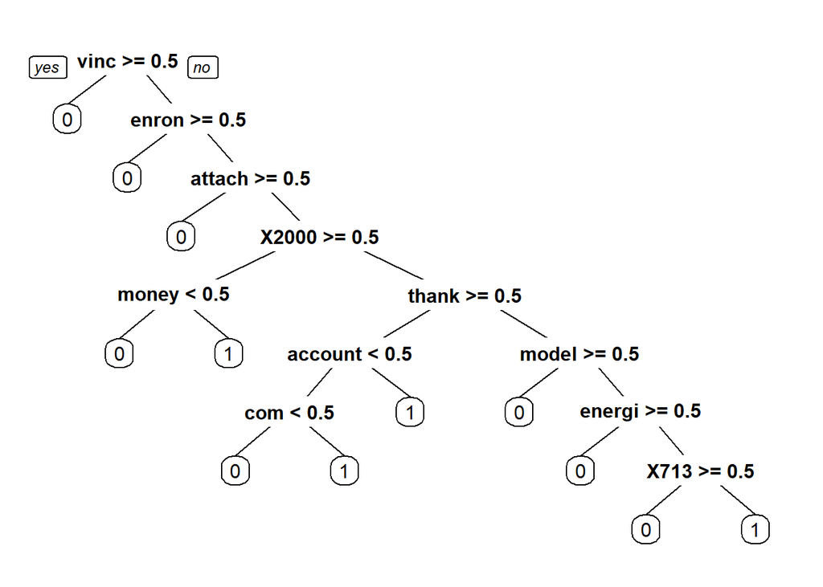

```r
prp(m.cart)
```

Recall that we suspect these word stems are specific to Vincent Kaminski and might affect the generalizability of a spam filter built with his ham data.

##### 3.4 What is the training accuracy of the GLM model?

```r
table(train$spam, p.glm > 0.5) %>% {sum(diag(.)) / sum(.)}
```

```
## [1] 0.999
```

##### 3.5 What is the training AUC of the GLM model?

```r
colAUC(p.glm, train$spam)
```

```
##         [,1]
## 0 vs. 1    1
```

##### 3.6 What is the training accuracy of the CART model?

```r
p.cart = predict(m.cart)[,2]
table(train$spam, p.cart > 0.5) %>% {sum(diag(.)) / sum(.)}
```

```
## [1] 0.94239
```

```r
colAUC(p.cart, train$spam)
```

```
##           [,1]
## 0 vs. 1 0.9696
```

##### 3.8 What is the training accuracy of the RF model?

```r
p.rf = predict(m.rf,type='prob')[,2]
table(train$spam, p.rf > 0.5) %>% {sum(diag(.)) / sum(.)}
```

```
## [1] 0.9808
```

```r
colAUC(p.rf, train$spam)
```

```
##           [,1]
## 0 vs. 1 0.9979
```

##### 3.10 Which model had the best training set performance, in terms of accuracy & AUC?

```r
pred = data.frame(glm=p.glm, cart=p.cart, rf=p.rf)
rbind(
  ACC= apply(pred, 2, function(x) {
    table(train$spam, x > 0.5) %>% {sum(diag(.)) / sum(.)} } ),
  colAUC(pred, train$spam)
  ) %>% t
```

```
##          ACC 0 vs. 1
## glm  0.99900  1.0000
## cart 0.94239  0.9696
## rf   0.98080  0.9979
```

### Problem 4 - Evaluating on the Test Set

Obtain predicted probabilities for the testing set for each of the models,

```r
pred2 = data.frame(
  glm = predict(m.glm, test, type='response'),
  cart = predict(m.cart, test)[,2],
  rf = predict(m.rf, test, type='prob')[,2] )
rbind(
  ACC = apply(pred2, 2, function(x) {
    table(test$spam, x > 0.5) %>% {sum(diag(.)) / sum(.)} } ),
  AUC = colAUC(pred2, test$spam)  ) %>% t
```

```
##          ACC 0 vs. 1
## glm  0.95052 0.96275
## cart 0.93946 0.96318
## rf   0.97555 0.99777
```

##### 4.1 ~ 4.6 ACC/AUC of the GLM/CART/RF models

see the table above

##### 4.7 Which model had the best testing set performance, in terms of accuracy and AUC?

- Random Forest

##### 4.7 Which model demonstrated the greatest degree of overfitting??

- Logistic Regression